# Zaman Serisi Analizi Vize

Yasemin Hızarcı 121516005

12 12 2020

## Kullanilan veri:

### Norvec’te Yeni Araba Satislari

### 2007-2017 icin aylik otomobil satislari

Norvec’teki otomobil satislarinin aylara gore ozet istatistikleri.

**Quantity(Miktar) Satilan toplam birim sayisi**

**Quantity_YoY** Birim cinsinden YY(bir onceki yilin ayni donemine kiyasla) degisim

**Import(ithalat)** Ithal edilen toplam birim sayisi

**Import_YoY** Birim cinsinden gecen yil ayni aya gore degisim.

**Used** Ulke icindeki birim sahibi degisikliklerinin toplam sayisi (2012 verileri mevcuttur)

**Used_YoY** Birim cinsinden YY degisim.

**Avg_CO2**- Belirli bir ayda satilan tum arabalarin ortalama CO2 emisyonu (g / km cinsinden)

**Bensin_Co2** - Belirli bir ayda satilan benzin yakitli arabalarin ortalama CO2 emisyonu (g / km cinsinden)

**Diesel_Co2** - Belirli bir ayda satilan dizel yakitli arabalarin ortalama CO2 emisyonu (g / km olarak)

**Quantity_Diesel** - Belirli bir ayda ulkede satilan dizel yakitli araba sayisi

**Diesel_Share** - Dizel arabalarin toplam satislar icindeki payi (Miktar Dizel / Miktar)

**Diesel_Share_LY** - Bir yil onceki toplam satislar icinde dizel arabalarin payi

**Quantity_Hybrid** - Ulkede satilan yeni hibrit otomobil sayisi (hem PHEV hem de BV)

**Quantity_Electric** - Ukede satilan yeni elektrikli otomobil sayisi.

**Import_Electric** - Ulkeye ithal edilen kullanilmis elektrikli otomobil sayisi

Not: Hibrit ve elektrikli otomobil satislarina iliskin rakamlar 2011’den once mevcut degildir

```r
library(fpp2)
```

```r
carsales<-read.csv(file="C:/Users/yasem/OneDrive/Belgeler/datas/norwaycarsales.csv",
                          header=TRUE,sep=",")

head(carsales)
```

```
##   Year Month Quantity Quantity_YoY Import Import_YoY Used Used_YoY Avg_CO2
## 1 2007     1    12685         5227   2276        257   NA       NA     152
## 2 2007     2     9793         2448   1992        -89   NA       NA     156
## 3 2007     3    11264         1445   2626         45   NA       NA     159
## 4 2007     4     8854          504   2220       -130   NA       NA     160
## 5 2007     5    12007         1592   2881          7   NA       NA     160
## 6 2007     6    11083         1545   3038         23   NA       NA     161
##   Bensin_Co2 Diesel_Co2 Quantity_Diesel Diesel_Share Diesel_Share_LY
## 1        155        152           10072         79.4            52.5
## 2        159        155            7222         73.7            47.4
## 3        161        158            7965         70.7            48.1
## 4        165        158            6116         69.1            48.4
## 5        163        159            8519         71.0            49.1
## 6        163        160            8290         74.8            49.5
##   Quantity_Hybrid Quantity_Electric Import_Electric
## 1              NA                NA              NA
## 2              NA                NA              NA
## 3              NA                NA              NA
## 4              NA                NA              NA
## 5              NA                NA              NA
## 6              NA                NA              NA
```

```r
summary(carsales)
```

```
##       Year          Month           Quantity      Quantity_YoY
##  Min.   :2007   Min.   : 1.000   Min.   : 5353   Min.   :-4548.0
##  1st Qu.:2009   1st Qu.: 3.000   1st Qu.:10250   1st Qu.: -526.0
##  Median :2012   Median : 6.000   Median :11385   Median :  493.0
##  Mean   :2012   Mean   : 6.455   Mean   :11134   Mean   :  392.6
##  3rd Qu.:2014   3rd Qu.: 9.000   3rd Qu.:12337   3rd Qu.: 1445.0
##  Max.   :2017   Max.   :12.000   Max.   :14207   Max.   : 5227.0
##
##      Import       Import_YoY         Used          Used_YoY
##  Min.   :1048   Min.   :-1810   Min.   :24106   Min.   :-6261.0
##  1st Qu.:1812   1st Qu.: -495   1st Qu.:34212   1st Qu.: -392.0
##  Median :2263   Median : -114   Median :37079   Median :  855.0
##  Mean   :2204   Mean   : -135   Mean   :36865   Mean   :  973.1
##  3rd Qu.:2625   3rd Qu.:  162   3rd Qu.:39797   3rd Qu.: 2708.0
##  Max.   :3768   Max.   : 1334   Max.   :44106   Max.   : 5896.0
##                                 NA's   :60      NA's   :72
##     Avg_CO2        Bensin_Co2      Diesel_Co2    Quantity_Diesel
##  Min.   : 84.0   Min.   : 94.0   Min.   :118.0   Min.   : 3422
##  1st Qu.:110.0   1st Qu.:120.0   1st Qu.:133.0   1st Qu.: 5434
##  Median :132.0   Median :131.0   Median :136.0   Median : 6583
##  Mean   :129.5   Mean   :133.7   Mean   :141.4   Mean   : 6582
##  3rd Qu.:151.0   3rd Qu.:150.0   3rd Qu.:151.0   3rd Qu.: 7808
##  Max.   :162.0   Max.   :165.0   Max.   :166.0   Max.   :10072
##
##   Diesel_Share   Diesel_Share_LY Quantity_Hybrid Quantity_Electric
##  Min.   :26.30   Min.   :38.00   Min.   : 159    Min.   :  43
##  1st Qu.:48.50   1st Qu.:49.40   1st Qu.: 443    1st Qu.: 309
##  Median :68.70   Median :68.70   Median : 899    Median :1260
##  Mean   :60.51   Mean   :62.28   Mean   :1255    Mean   :1154
##  3rd Qu.:73.70   3rd Qu.:74.00   3rd Qu.:1556    3rd Qu.:1906
##  Max.   :81.40   Max.   :81.40   Max.   :4419    Max.   :3391
##                                  NA's   :48      NA's   :48
##  Import_Electric
##  Min.   : 33.0
##  1st Qu.:197.0
##  Median :286.0
##  Mean   :306.9
##  3rd Qu.:433.0
##  Max.   :746.0
##  NA's   :68
```

Aylik toplam araba satislarini belirten “Quantity” degiskenini ts() ile zaman serisi verisi haline getiriyorum.

```r
Quantity <- ts(carsales$Quantity, start = c(2007,1), frequency = 12)
Quantity
```

```
##        Jan   Feb   Mar   Apr   May   Jun   Jul   Aug   Sep   Oct   Nov   Dec
## 2007 12685  9793 11264  8854 12007 11083 12062 10786  9340 11646 10453  9222
## 2008  9901 10567  9506 11704 10217  9670  9605  7833  8453  8390  6952  7819
## 2009  5353  6287  7601  7504  7421  7581  9394  7967  9530 10187  9600 10250
## 2010  9697  9094 11486 10677  9896 11119 11507 10414 11137 10683 11908 10136
## 2011 10372 10543 12901 11330 13005 10354 11189 11464 11737 11543 12357 11550
## 2012 10838 10925 13051 10876 12612 11053 11920 11790 11134 12413 11986  9369
## 2013 11639 11322 10735 13988 12012 10948 11312 11660 12168 12893 12079 11395
## 2014 11385 11246 13861 12115 12337 11441 11690 11444 11585 12963 11486 12649
## 2015 10523 10685 14159 12782 12036 14207 12394 12604 12421 13197 12600 13078
## 2016 10991 12222 13875 14116 12864 13681 11040 13232 13854 11932 13194 13602
## 2017 13055
```

# **Soru1**

**Veri setinize iliskin zaman serisi grafigini cizdiriniz. Veri setinizde trend ve mevsimsellik var midir? Eger mevsimsellik oldugunu dusunuyorsaniz ilgili mevsimsellik grafiklerini (seasonal plot) cizdiriniz. Yorumlayiniz.**

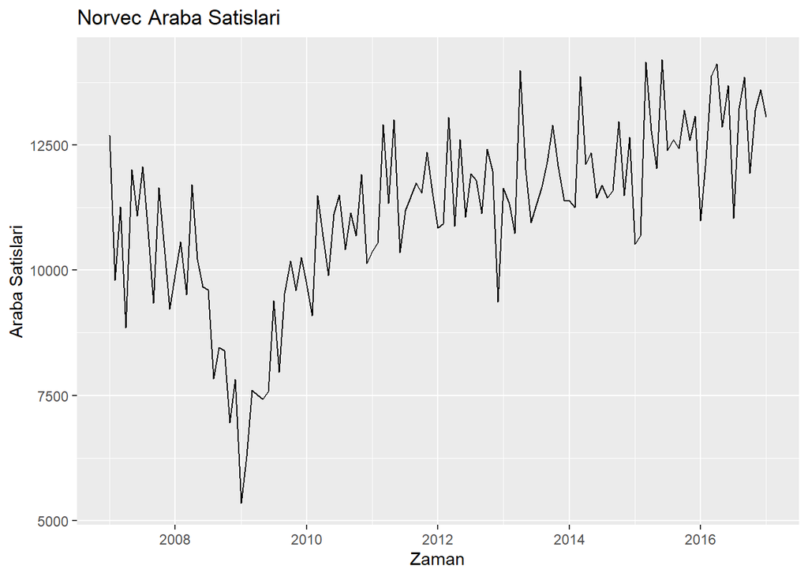

```r
autoplot(Quantity) +
ggtitle("Norvec Araba Satislari ") +
xlab("Zaman") +
ylab("Araba Satislari")
```

2009 dan itibaren artan bir trend vardir.

Mevsimselligi daha detayli incelemek istiyorum.

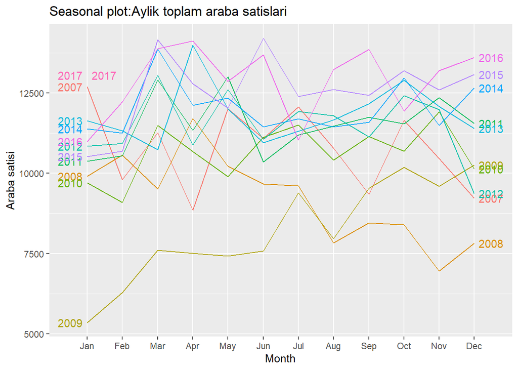

```r
ggseasonplot(Quantity, year.labels=TRUE, year.labels.left=TRUE) +
ylab("Araba satisi") +
ggtitle("Seasonal plot:Aylik toplam araba satislari")
```

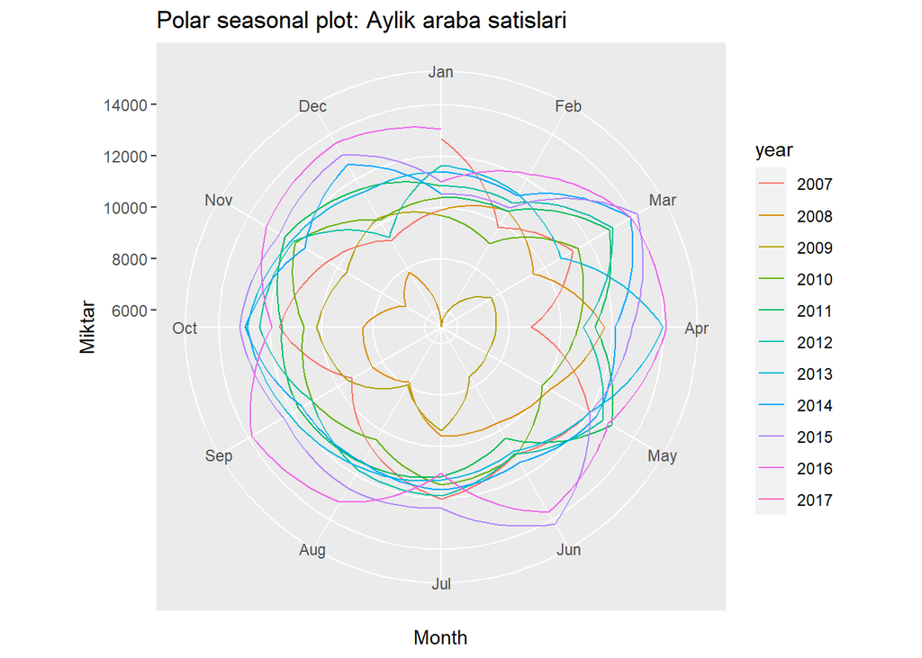

```r
ggseasonplot(Quantity, polar=TRUE) +
ylab("Miktar") +
ggtitle("Polar seasonal plot: Aylik araba satislari")
```

Mevsimsellik ozellikleri anlamli degildir.

# **Soru2**

**Verinize iliskin otokorelasyon (ACF) grafigi cizdiriniz ve yorumlayiniz.**

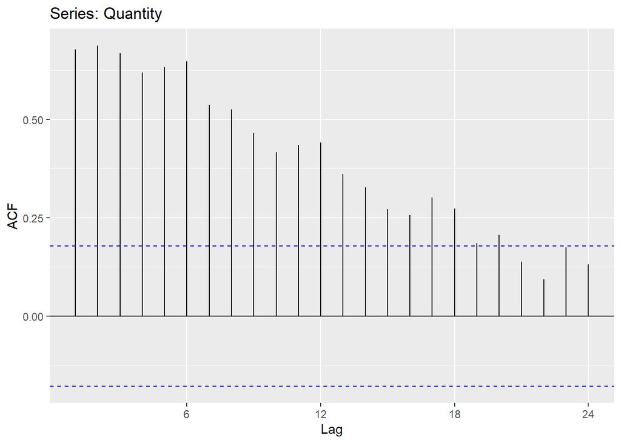

```r
ggAcf(Quantity)
```

Dikey cizgiler mavi kesikli cizgi ile belirtilen sinirlar icinde degildir.Cizgilerin bu sinirlari asmasi otokorelasyon oldugunun kanitidir.Bu zaman serisi beyaz gurultu serisi degildir.

Gecikmeler arttikca ACF’deki yavas dusus trendden kaynaklanmaktadir. “tarakli” sekil yani mevsimsellik belirtisi guclu degildir..

# **Soru3**

**Verinizi egitim ve test (train, test) olarak iki parcaya ayirin.**

```r
train<-window(Quantity,end=c(2014,12))#ilk 96 ayi train olarak aldim.
test<-window(Quantity, start=c(2015,1)) #son 25 ayi test seti olarak aldim.
```

## a)

**Egitim setinizi, ortalama, naive, box-cox donusumlu naive metod (veri setinize uygun olan naive metod) kullanarak modelleyiniz.**

**15 ayin tahmini icin:**

```r
lambda <- BoxCox.lambda(train)
lambda
```

```
## [1] 1.999924
```

train verisini kullanarak sonraki 15 ayi tahmin etmek istedigim icin h=15 aldim.

```r
#ortalama
fit1<-meanf(train, h=15)

#naive
fit2<-rwf(train, h=15)

#box-cox donusumlu naive
fit3=rwf(train, lambda=BoxCox.lambda(train),drift=TRUE, h=15,level=10)
```

## b)

**Bu uc modelin test seti uzerindeki performansini gosteren zaman serisi grafigi cizdiriniz.**

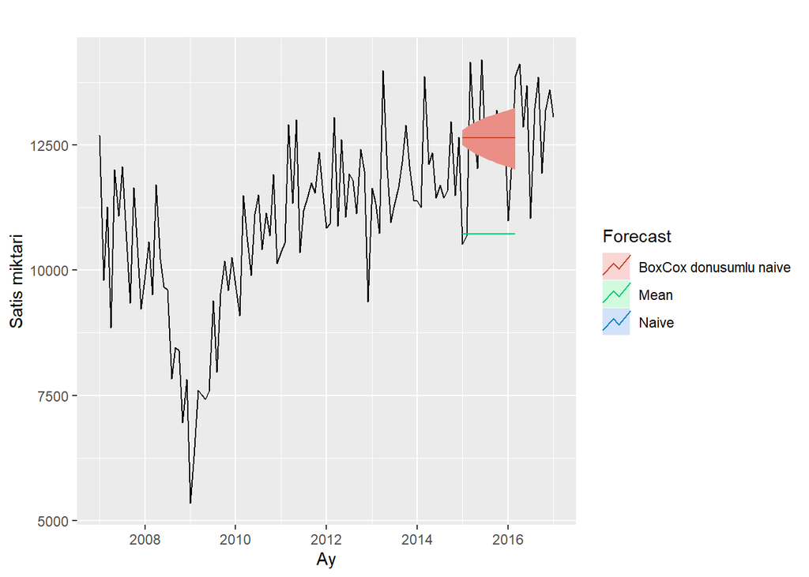

```r
autoplot(Quantity) +
autolayer(fit1, series="Mean",PI=FALSE) +
autolayer(fit2, series="Naive",PI=FALSE) +
autolayer(fit3, series="BoxCox donusumlu naive") +
xlab("Ay") + ylab("Satis miktari") +
guides(colour=guide_legend(title="Forecast"))
```

2015`e kadar olan gozlemler train verisindedir.2015 in birinci ayindan itibaren de test verisine ait gozlemler vardir.Train verisi kullanilarak(2015 yilina kadar olan gozlemler kullanilarak) sonraki 15 ay tahmin edilmistir.Siyah cizgiler orijinal gozlemlerdir.Yesil cizgi 15 ay icin ortalama tahminidir.Kırmızı cizgi BoxCox donusumlu naive tahminidir.Naive tahmini ise BoxCox donusumlu tahminin altinda kaldigi icin gorunmemistir.Grafige bakarak ortalama tahmininin bu model icin pek uygun olmadigi sonucuna varilabilir.BoxCox ve Naive tahmini daha uygun gorunmektedir.

## c)

**Modellerin test seti uzerindeki performanslarini MAPE ve RMSE kriterlerine gore kiyaslayiniz.**

```r
accuracy(fit1, test)
```

```
##                         ME     RMSE      MAE       MPE     MAPE      MASE
## Training set -6.059678e-13 1645.324 1281.418 -2.974167 13.44519 0.8640506
## Test set      1.800496e+03 2111.692 1830.835 13.688732 13.97641 1.2345183
##                     ACF1 Theil's U
## Training set  0.65007095        NA
## Test set     -0.04692389  1.402789
```

```r
accuracy(fit2, test)
```

```
##                        ME     RMSE       MAE        MPE      MAPE      MASE
## Training set   -0.3789474 1354.446 1094.0421 -0.8598086 10.484533 0.7377045
## Test set     -130.7333333 1111.103  851.2667 -1.8636469  7.055695 0.5740028
##                     ACF1 Theil's U
## Training set -0.53832604        NA
## Test set     -0.04692389 0.6742106
```

```r
accuracy(fit3, test)
```

```
##                         ME     RMSE       MAE        MPE      MAPE      MASE
## Training set    0.08310308 1354.477 1094.0548 -0.8552378 10.484459 0.7377130
## Test set     -127.69696995 1111.155  850.7606 -1.8395419  7.050332 0.5736616
##                     ACF1 Theil's U
## Training set -0.53832601        NA
## Test set     -0.04670802 0.6743138
```

Mean: MAPE:13.97641, RMSE:2111.692

Naive: MAPE:7.055695, RMSE:1111.103

Box-Cox donusumlu naive: MAPE:7.050332, RMSE:1111.155

En yuksek MAPE ve RMSE degerleri Mean yontemindedir.Diger yontemlere gore bu degerler cok daha yuksek cikmistir ve bu durum bize mean yonteminin bu model icin en kotu tahmin yontemi oldugunu gosterir.

Naive ve Box-Cox donusumlu Naive`de MAPE ve RMSE sonuclari birbirine yakindir.

En iyi yontemin ise naive yontemi oldugu gorulmektedir.RMSE degeri digerlerinden daha dusuktur.

## d)

**Modellerin performansini, training seti cross validation artiklari (h=1 adim) uzerinden hesaplanan RMSE degerlerine gore karsilastiriniz.**

```r
#mean
e <- tsCV(train, meanf, h=1)
RMSEmean<-sqrt(mean(e^2, na.rm=TRUE))

#naive
e <- tsCV(train, rwf, h=1)
RMSEnaive<-sqrt(mean(e^2, na.rm=TRUE))

#Box-Cox
e <- tsCV(train, rwf,drift=TRUE,lambda=1.999924, h=1)
RMSEBoxCoxNaive<-sqrt(mean(e^2, na.rm=TRUE))
```

```r
RMSEmean
```

```
## [1] 1695.183
```

```r
RMSEnaive
```

```
## [1] 1354.446
```

```r
RMSEBoxCoxNaive
```

```
## [1] 1511.694
```

training seti cross validation artiklari (h=1 adim) uzerinden hesaplanan RMSE degerlerine gore en iyi model naive modeldir.

## e)

**Naive modelin artiklari icin otokorelasyon varsayimini, uygun gecikme sayisini belirledikten sonra Portmanteau testler yardimiyla test ediniz.**

```r
res <- residuals(naive(Quantity))
```

**H0 : Seri beyaz gurultu serisidir** **H1 : Otokorelasyon problemi vardir**

### Box-Pierce test:

mevsimsellik olmadigi icin gecikme 10 alinmistir.

```r
Box.test(res, lag=10, fitdf=0)
```

```
##
##  Box-Pierce test
##
## data:  res
## X-squared = 46.183, df = 10, p-value = 1.329e-06
```

### Box-Ljung test:

```r
Box.test(res,lag=10, fitdf=0, type="Lj")
```

```
##
##  Box-Ljung test
##
## data:  res
## X-squared = 48.033, df = 10, p-value = 6.121e-07
```

Ho reddedilir.Otokorelasyon problemi vardir.

## f)

**Naive modelin artiklari icin normallik varsayimini test ediniz, test sonucunuza gore, test seti uzerindeki tahminleriniz icin uygun %80 lik tahmin araligini belirleyiniz.**

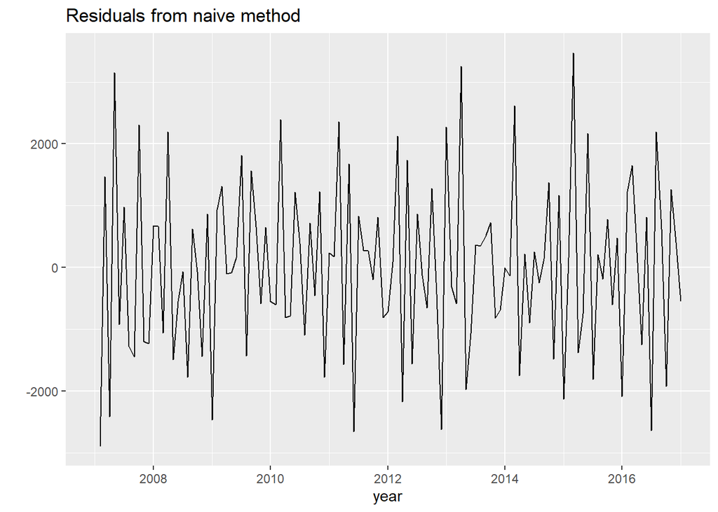

```r
autoplot(res) + xlab("year") + ylab("") +
ggtitle("Residuals from naive method")
```

Grafige gore artiklar 0 etrafinda duzenli olarak dagilmaktadir.

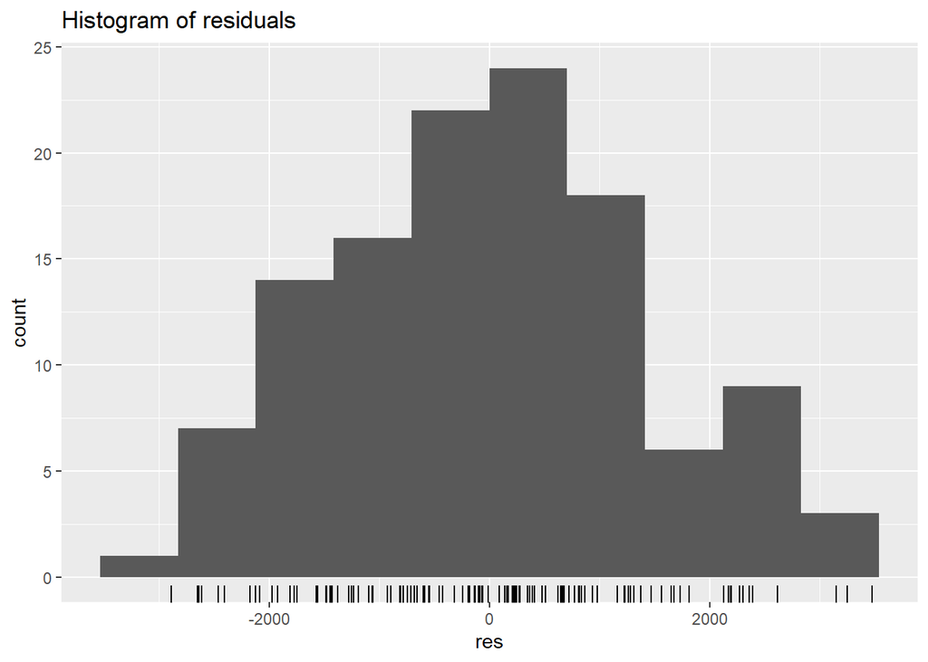

```r
gghistogram(res) + ggtitle("Histogram of residuals")
```

Histogram sonucuna gore Naive modelin artiklarinin normal dagilima yakin oldugu goruluyor.

# **Soru4:**

**Training set uzerinde regresyon modeli kurarak trend ve mevsimselligi inceleyiniz. Modelin test ve training set uzerindeki tahmin performansini incelemek icin zaman serisi grafigi cizdiriniz. Test seti icin RMSE degerini hesaplayiniz.**

```r
fit.quantity <- tslm(train ~ trend + season)
summary(fit.quantity)
```

```
##
## Call:
## tslm(formula = train ~ trend + season)
##
## Residuals:
##     Min      1Q  Median      3Q     Max
## -4298.6  -574.8    63.8   801.5  3809.5
##
## Coefficients:
##             Estimate Std. Error t value Pr(>|t|)
## (Intercept) 8843.125    548.072  16.135  < 2e-16 ***
## trend         32.340      5.245   6.166 2.42e-08 ***
## season2     -293.965    706.455  -0.416    0.678
## season3     1002.195    706.514   1.419    0.160
## season4      550.230    706.611   0.779    0.438
## season5      825.265    706.747   1.168    0.246
## season6       10.674    706.922   0.015    0.988
## season7      657.084    707.136   0.929    0.355
## season8      -40.381    707.389  -0.057    0.955
## season9      143.029    707.681   0.202    0.840
## season10     814.939    708.011   1.151    0.253
## season11     295.474    708.380   0.417    0.678
## season12    -290.741    708.787  -0.410    0.683
## ---
## Signif. codes:  0 '***' 0.001 '**' 0.01 '*' 0.05 '.' 0.1 ' ' 1
##
## Residual standard error: 1413 on 83 degrees of freedom
## Multiple R-squared:  0.3625, Adjusted R-squared:  0.2703
## F-statistic: 3.932 on 12 and 83 DF,  p-value: 8.71e-05
```

Her ayda ortalama 32 araba fazla satis var. Ortalama olarak ikinci ayda ilk aya gore 293 dusuk satis vardir.Ucuncu ayda ilk aya gore 1002 fazla satis vardir.Diger aylarda da ilk aya gore artis ve azalislar olmustur.

trend anlamli cikmistir. Mevsimsellik ise anlamli degildir.

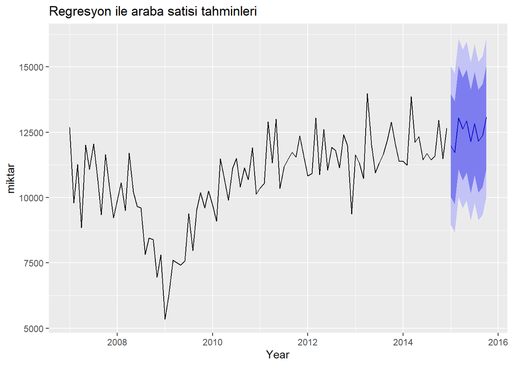

```r
fit.quantity <- tslm(train ~ trend + season)
fcast <- forecast(fit.quantity)
autoplot(fcast) +
ggtitle("Regresyon ile araba satisi tahminleri") +
xlab("Year") + ylab("miktar")
```

Koyu golgeli bolge %80 tahmin araliklarini gosterir ve acik golgeli bolge %95 tahmin araliklarini gosterir.

**Test seti icin RMSE degeri**

```r
accuracy(fcast, test)
```

```
##                        ME      RMSE      MAE        MPE      MAPE      MASE
## Training set 1.136868e-13 1313.7298 956.9642 -1.9959091 10.114074 0.6452739
## Test set     8.246429e+00  993.8439 773.5643 -0.6360074  6.266847 0.5216087
##                    ACF1 Theil's U
## Training set  0.5376100        NA
## Test set     -0.2568682 0.5754254
```

RMSE:993.8439

…